# STA 108 Discussion 6

Shozen Dan

11/14/2019

For this dicussion we will use the cats dataset from the MASS library. The dat represents the body weight(kg), heart weight(grams), and gender of cats.

```r
library(MASS)
library(ggplot2)
```

## 1. Conduct a multiple linear regression analysis to test if body weight depends on hear weight and gender

```r
summary(cats)
```

```
 Sex         Bwt             Hwt
 F:47   Min.   :2.000   Min.   : 6.30
 M:97   1st Qu.:2.300   1st Qu.: 8.95
        Median :2.700   Median :10.10
        Mean   :2.724   Mean   :10.63
        3rd Qu.:3.025   3rd Qu.:12.12
        Max.   :3.900   Max.   :20.50
```

### (a) Plot the data

We can produce a simple plot by calling plot() on cats.

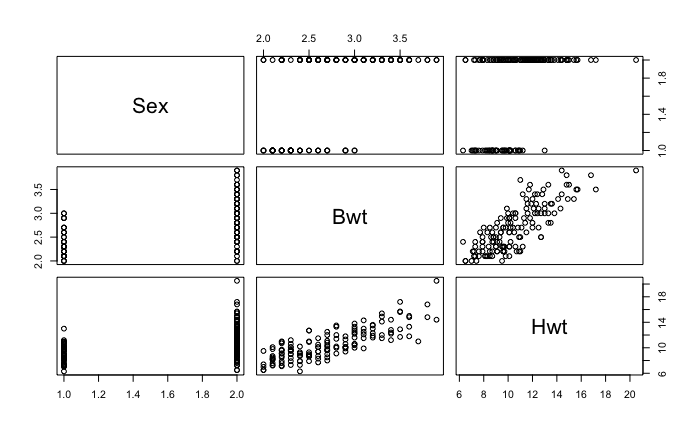

```r
plot(cats)
```

To plot multiple regression lines based on categorical variables, we can pass the Sex variable to color in the aesthetics of the ggplot function.

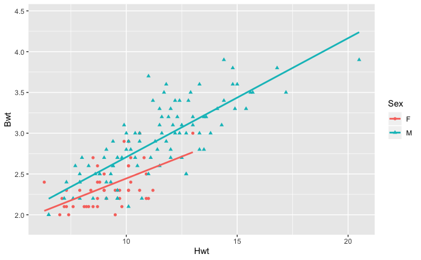

```r
ggplot(cats, aes(y = Bwt, x = Hwt, colour=Sex, shape=Sex)) + geom_point() + geom_smooth(method="lm", fill = NA)
```

### (b) Test the assumption $\varepsilon_{i} ~ Normal(0,\sigma_{\varepsilon}^2)$

We can test for normality of errors by fitting the linear model and conducting a Shapiro-Wilk normality test

```r
lm.fit = lm(Bwt~., data = cats)
shapiro.test(lm.fit$residuals)
```

```
    Shapiro-Wilk normality test

data:  lm.fit$residuals
W = 0.99258, p-value = 0.6597
```

Because the p-value is much greater than 0.1 we cannot reject the null hypothesis and thus conclude that the distribution of errors is normal.

### (c) State the multiple linear regression model.

```r
summary(lm.fit)
```

```
Call:
lm(formula = Bwt ~ ., data = cats)

Residuals:
    Min      1Q  Median      3Q     Max
-0.6274 -0.1804 -0.0174  0.1699  0.8456

Coefficients:
            Estimate Std. Error t value Pr(>|t|)
(Intercept)  1.06022    0.10197  10.398  < 2e-16 ***
SexM         0.24100    0.05284   4.561  1.1e-05 ***
Hwt          0.14120    0.01021  13.826  < 2e-16 ***
---
Signif. codes:  0 ‘***’ 0.001 ‘**’ 0.01 ‘*’ 0.05 ‘.’ 0.1 ‘ ’ 1

Residual standard error: 0.2712 on 141 degrees of freedom
Multiple R-squared:  0.692, Adjusted R-squared:  0.6877
F-statistic: 158.4 on 2 and 141 DF,  p-value: < 2.2e-16
```

The statistical tests for the intercept and the coefficients were all significant.

### (d) Use the predict function to predict the bodyweight of a female cat with a heart weight of 2 grams

```r
predict(lm.fit, data.frame(Sex = 'F', Hwt = 2))
```

```
      1
1.34262
```

The body weight of a female cat with a heart weight of 2 grams is expected to be, on average, 1.34262 kg.

### (e) Calculate the Bonferroni and Scheffe multipliers and construct 5 prediction intervals, at Hwt = 1 to 5 and Sex = “M”, “M”, “M”, “F”, “F”

#### Bonferroni method (95% simultaneous prediction interval)

```r
Bonf.pred = predict(lm.fit, data.frame(Sex = c('M', 'M', 'M', 'F', 'F'), Hwt = 1:5), interval = 'prediction', level = 1-0.05/5)
print(Bonf.pred)
```

```
       fit       lwr      upr
1 1.442418 0.6792180 2.205618
2 1.583620 0.8296279 2.337612
3 1.724822 0.9791973 2.470446
4 1.625024 0.8960227 2.354026
5 1.766226 1.0418259 2.490626
```

#### Scheffe’s method

```r
p = 3
g = 5
n = dim(cats)[1]
X = model.matrix(lm.fit)
middle.part = solve(t(X)%*%X)
X.new = cbind(1, c(1, 1, 1, 0, 0), 1:5)
sigma.hat = summary(lm.fit)$sigma
width.half = sqrt(g*qf(0.95, g, n-p)*(1+apply(X.new, 1, function(x){t(x)%*%middle.part%*%x})))*sigma.hat
Schef.pred = matrix(rep(predict(lm.fit, data.frame(Sex = c('M','M','M','F','F'), Hwt = 1:5)), 2), ncol = 2)
Schef.pred[, 1] = Schef.pred[, 1] - width.half
Schef.pred[, 2] = Schef.pred[, 2] + width.half
colnames(Schef.pred) = c('lwr', 'upr')
print(Schef.pred)
```

```
           lwr      upr
[1,] 0.4558949 2.428941
[2,] 0.6089992 2.558240
[3,] 0.7610171 2.688626
[4,] 0.6827065 2.567342
[5,] 0.8298562 2.702596
```

### (f): Construct multiple 95% confidence intervals for the β’s by using the Bonferroni correction. To do so in R, use the confint function and replace α with 1−α/g. Interpret the confidence intervals for β1 and β2.

```r
confint(lm.fit, level = 1-0.05/3)
```

```
              0.833 %  99.167 %
(Intercept) 0.8131650 1.3072679
SexM        0.1129665 0.3690324
Hwt         0.1164577 0.1659461
```

Interpretation: We are overall 95% confident that the body weight of a cat will increase, on average, 0.116 and 0.166 kilogram when heart weight increases by 1 gram, and male cats are, on average, between 0.113 to 0.369 kilograms heavier than female cats.